# Проект для «Викишоп»

## Подготовка

```python
#pip install wordcloud
```

```python
#pip install -U spacy
```

```python
#pip install -U scikit-learn scipy matplotlib
```

```python
#pip install imblearn
```

```python
#pip install lightgbm
```

```python
import pandas as pd
import numpy as np

from wordcloud import WordCloud
import matplotlib.pyplot as plt
%matplotlib inline

import os

import re
import spacy
import random

from tqdm import tqdm
from sklearn.pipeline import Pipeline
from sklearn.feature_extraction.text import TfidfVectorizer
from sklearn.feature_extraction.text import CountVectorizer

from sklearn.model_selection import train_test_split, cross_val_score, GridSearchCV
from sklearn.linear_model import LogisticRegression
from sklearn.tree import DecisionTreeClassifier
from sklearn.ensemble import RandomForestClassifier
from sklearn.linear_model import PassiveAggressiveClassifier

from lightgbm import LGBMClassifier

from sklearn.dummy import DummyClassifier
from sklearn.metrics import f1_score

from imblearn.over_sampling import SMOTE
from imblearn.under_sampling import RandomUnderSampler
```

```python
data_path = '/datasets/toxic_comments.csv'
pc_data_path = 'toxic_comments.csv'
colab_data_path = '/content/toxic_comments.csv'

if os.path.exists(data_path):
    data = pd.read_csv(data_path, index_col=[0])
elif os.path.exists(pc_data_path):
    data = pd.read_csv(pc_data_path, index_col=[0])
elif os.path.exists(colab_data_path):
    data = pd.read_csv(colab_data_path ,index_col=[0])
else:
    print('Не удалось загрузить данные! Неверный путь.')
```

```python
STATE = 12345
```

```python
data.info()
```

```
<class 'pandas.core.frame.DataFrame'>
Index: 159292 entries, 0 to 159450
Data columns (total 2 columns):
 #   Column  Non-Null Count   Dtype
---  ------  --------------   -----
 0   text    159292 non-null  object
 1   toxic   159292 non-null  int64
dtypes: int64(1), object(1)
memory usage: 3.6+ MB
```

```python
data.sample(10)
```

|  | text | toxic |
| --- | --- | --- |
| 14862 | sorry about the editing about max hohar but it... | 1 |
| 139711 | Removal of relevant links and content to a pag... | 0 |
| 112424 | Where what when? If recently than not on purpo... | 0 |
| 3107 | "\n\n Thank you! \n\n The Barnstar of Good Hu... | 0 |
| 24201 | January 2013 (UTC)\n\nDo not call me a sock, y... | 1 |
| 710 | Regarding the Verifiability mediation, you wil... | 0 |
| 142512 | You don't seem to understand what a personal a... | 0 |
| 83854 | JUDENSCWEIN TO THE OVENS ! LIARS ! ALL OF YOU ! | 1 |
| 20037 | Hello Theirrulez! | 0 |
| 87215 | "\n\n Power of a Constable \n\nHello I notice... | 0 |

```python
print('Дубликатов: ', data.duplicated().sum())
print('Пропусков: ', data.isna().sum().sum())
```

```
Дубликатов:  0
Пропусков:  0
```

Используем модуль tqdm для отслеживания процесса выполнения команд. Подгрузим словань английских слов.

```python
tqdm.pandas()
nlp = spacy.load('en_core_web_sm', disable=['parser', 'ner'])
```

Создадим функцию с помощью библиотеки spacy, которая удалит из комментариев цифры, символы, пробелы, "стоп" слова и приведёт оставшиеся к нормальной форме.

```python
def lemmatize_spacy(text):
    lemma_list = list()
    text = text.lower()
    for token in nlp(text):
        if not ((token.is_stop) or (token.pos_ in ('PUNCT', 'NUM', 'SPACE', 'SYM'))):
            lemma_list.append(token.lemma_)
    return " ".join(lemma_list)
```

```python
data['lemm_text'] = data['text'].progress_apply(lemmatize_spacy)
```

Выведем результат преобразования случайно выбранной строки

```python
str = random.randint(0, 125)
print('OLD:\n', '\n', data['text'][str])
print('\nNEW:\n\n', data['lemm_text'][str])
```

```
OLD:

 Including some appropriate mention of the Solomon article is not without some level of support .

NEW:

 include appropriate mention solomon article level support
```

Удаляем пустые строки после лемматизации

```python
data.dropna(inplace=True)
```

Построим облака слов для каждой группы комментариев.

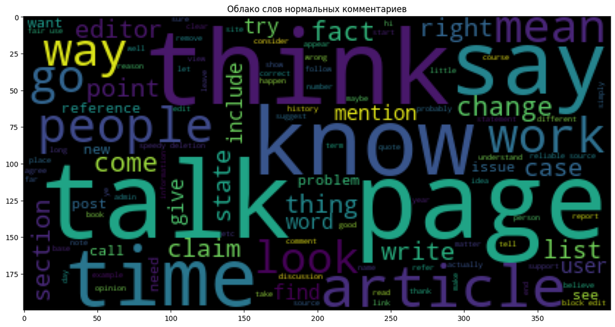

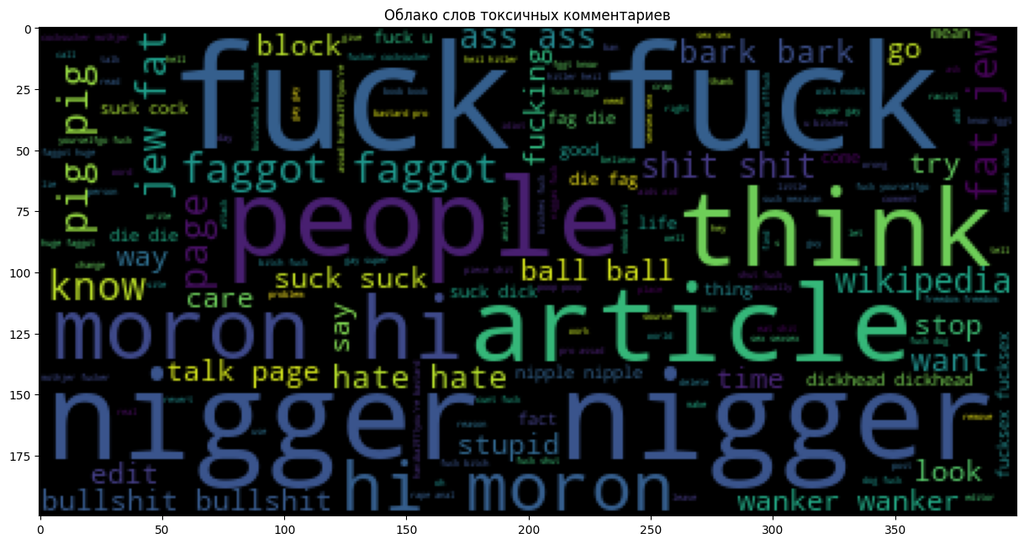

```python
#wordcloud = WordCloud().generate(' '.join(data['lemm_text']))
wordcloud_toxic = WordCloud().generate(' '.join(data[data['toxic'] == 1]['lemm_text']))
wordcloud_non_toxic = WordCloud().generate(' '.join(data[data['toxic'] != 1]['lemm_text']))
plt.figure(figsize=(15,15))
plt.title('Облако слов нормальных комментариев')
plt.imshow(wordcloud_non_toxic)
plt.show()
plt.figure(figsize=(15,15))
plt.title('Облако слов токсичных комментариев')
plt.imshow(wordcloud_toxic)
plt.show()
```

Как видим не все слова из облака токсичных комментариев действительно являются признаком токсичности несмтря на то, что они довольно часто встречаются (people, know, think, hi).

## Обучение

Посмотрим как распределены комментарии в пропорции

```python
data['toxic'].value_counts()
```

```
toxic
0    143106
1     16186
Name: count, dtype: int64
```

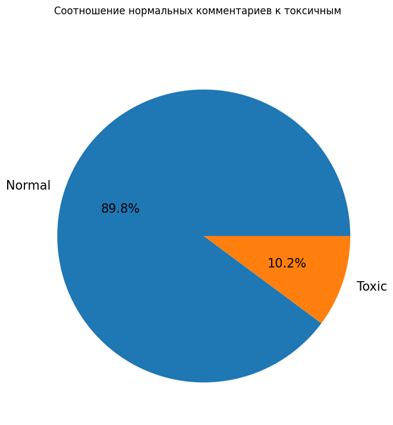

```python
(data['toxic'].value_counts().plot(kind='pie',
                                   title = 'Соотношение нормальных комментариев к токсичным',
                                   ylabel='',
                                   labels=['Normal', 'Toxic'],
                                   subplots=True,
                                   autopct="%.1f%%",
                                   fontsize=15,
                                   figsize=(8, 8)));
```

Разделим все комментарии на выборки в соотношении 80:10:10 сохраняя баланс классов.

```python
features = data['lemm_text']
target = data['toxic']

features_train, features_tmp, target_train, target_tmp = train_test_split(
    features, target, test_size=.2, random_state=STATE, stratify=target)
features_valid, features_test, target_valid, target_test = train_test_split(
    features_tmp, target_tmp, test_size=.5, random_state=STATE, stratify=target_tmp)

display(features.shape)
display(features_train.shape)
display(features_valid.shape)
display(features_test.shape)
```

```
(159292,)
```

```
(127433,)
```

```
(15929,)
```

```
(15930,)
```

Преобразуем слова в комментариях в вектора с помощью TfidfVectorizer.

```python
count_tf_idf = TfidfVectorizer()
tf_idf = count_tf_idf.fit_transform(features_train)
display(tf_idf.shape)

### Для деревьев:
count_tf_idf2 = TfidfVectorizer(max_features = 7000)
tf_idf2 = count_tf_idf2.fit_transform(features_train)
display(tf_idf2.shape)
```

```
(127433, 147981)
```

```
(127433, 7000)
```

Применим TfidfVectorizer к валидационной и тестовой выборкам.

```python
tf_idf_valid = count_tf_idf.transform(features_valid)
display(tf_idf_valid.shape)

tf_idf_test = count_tf_idf.transform(features_test)
display(tf_idf_test.shape)

### Для деревьев:
tf_idf_valid2 = count_tf_idf2.transform(features_valid)
display(tf_idf_valid2.shape)

tf_idf_test2 = count_tf_idf2.transform(features_test)
display(tf_idf_test2.shape)
```

```
(15929, 147981)
```

```
(15930, 147981)
```

```
(15929, 7000)
```

```
(15930, 7000)
```

### Обучим модель логистической регрессии.

Обучим модель с ипользованием GridSearchSV для подбора оптимальных гиперпараметров, предварительно применив векторизацию текста.

```python
%%time
pipeline = Pipeline([('vectorizer', TfidfVectorizer()),
                     ('log_regr', LogisticRegression())])

param_grid = {'log_regr__C': [0.001, 0.01, 0.1, 5, 15, 50],
              'log_regr__max_iter': [50, 100, 300],
              'log_regr__class_weight': ['balanced'],
              'log_regr__random_state': [STATE]}

clf = GridSearchCV(pipeline, param_grid, scoring='f1', cv=5, verbose=True, n_jobs=-1)
best_clf = clf.fit(features_train, target_train)
model = best_clf.best_estimator_
predicted_valid = best_clf.predict(features_valid)
best_f1 = f1_score(target_valid, predicted_valid)
display(best_f1)
display(best_clf.best_params_)
```

```
Fitting 5 folds for each of 18 candidates, totalling 90 fits
```

```
0.7736063708759955
```

```
{'log_regr__C': 5,
 'log_regr__class_weight': 'balanced',
 'log_regr__max_iter': 300,
 'log_regr__random_state': 12345}
```

```
CPU times: total: 45.6 s
Wall time: 2min 24s
```

Лучший результат **F1 = 0.77** на валидационной выборке нам подходит.

### Обучим пассивно-агрессивную модель

```python
pipeline = Pipeline([('vectorizer', TfidfVectorizer()),
                     ('pass_aggr', PassiveAggressiveClassifier())])

param_grid = {'pass_aggr__C': [0.001, 0.01, 0.1, 5, 15, 50],
              'pass_aggr__max_iter': [50, 100, 300],
              'pass_aggr__class_weight': ['balanced'],
              'pass_aggr__random_state': [STATE]}

clf2 = GridSearchCV(pipeline, param_grid, scoring='f1', cv=5, verbose=True, n_jobs=-1)
best_clf2 = clf2.fit(features_train, target_train)
predicted_valid = best_clf2.predict(features_valid)
display(f1_score(target_valid, predicted_valid))
display(best_clf2.best_params_)
```

```
Fitting 5 folds for each of 18 candidates, totalling 90 fits
```

```
0.7624827586206896
```

```
{'pass_aggr__C': 0.01,
 'pass_aggr__class_weight': 'balanced',
 'pass_aggr__max_iter': 100,
 'pass_aggr__random_state': 12345}
```

Данная модель справилась с задачей немного хуже логистической регрессии, тем не менее скорость обучения модели выше.  
**f1 = 0.76**

### Обучим модели дерева решений.

Обучим модели

```python
%time
pipeline = Pipeline ([('vectorizer', TfidfVectorizer(max_features=7000)),
                      #('over', SMOTE()),
                      #('under', RandomUnderSampler()),
                      ('des_tree', DecisionTreeClassifier())])

param_grid = {'des_tree__max_depth': range(10, 60, 6),
              'des_tree__class_weight': ['balanced'],
              'des_tree__random_state': [STATE]}

clf3 = GridSearchCV(pipeline, param_grid, scoring='f1', cv=3, verbose=True, n_jobs=-1)
best_clf3 = clf3.fit(features_train, target_train)
predicted_valid = best_clf3.predict(features_valid)
display(f1_score(target_valid, predicted_valid))
display(best_clf2.best_params_)
```

```
CPU times: total: 0 ns
Wall time: 0 ns
Fitting 3 folds for each of 9 candidates, totalling 27 fits
```

```
0.676378772112383
```

[output not shown]

```python
oversample = SMOTE(random_state=STATE)
undersample = RandomUnderSampler(random_state=STATE)
features_upsampled, target_upsampled = oversample.fit_resample(tf_idf2, target_train)
features_downsampled, target_downsampled = undersample.fit_resample(tf_idf2, target_train)
```

```python
%%time

best_f1 = 0
best_depth=0
for depth in tqdm(range(10, 60, 6)):
    model = DecisionTreeClassifier(random_state=STATE, max_depth=depth)
    model.fit(features_upsampled,target_upsampled)
    predict_valid = model.predict(tf_idf_valid2)
    result = f1_score(target_valid, predict_valid)
    if result > best_f1:
        best_f1 = result
        best_depth = depth

print(f'** F1: {best_f1} (max_depth: {best_depth}), UPSAMPLED **')
```

```
** F1: 0.6602011494252874 (max_depth: 28), UPSAMPLED **
CPU times: total: 12min 11s
Wall time: 12min 11s
```

```python
%%time

best_f1 = 0
best_depth=0
for depth in tqdm(range(10, 60, 6)):
    model = DecisionTreeClassifier(random_state=STATE, max_depth=depth)
    model.fit(features_downsampled,target_downsampled)
    predict_valid = model.predict(tf_idf_valid2)
    result = f1_score(target_valid, predict_valid)
    if result > best_f1:
        best_f1 = result
        best_depth = depth

print(f'** F1: {best_f1} (max_depth: {best_depth}), DOWNSAMPLED **')
```

```
** F1: 0.6435488909715714 (max_depth: 34), DOWNSAMPLED **
CPU times: total: 1min 9s
Wall time: 1min 9s
```

Лучший результат на валидационной выборке модель дерева решений показала **F1 = 0.68**

### Модель LightGBM

```python
%%time
pipeline = Pipeline ([('vectorizer', TfidfVectorizer()),
                      ('lgbm', LGBMClassifier())])

param_grid = {'lgbm__n_estimators': [100, 500, 1000],
              'lgbm__learning_rate': [0.1, 0.3, 0.5],
              'lgbm__class_weight': ['balanced']}

clf_lgbm = GridSearchCV(pipeline, param_grid, scoring='f1', cv=5, verbose=True, n_jobs=-1)
best_clf_lgbm = clf_lgbm.fit(features_train, target_train)
predicted_valid = best_clf_lgbm.predict(features_valid)
best_f1 = f1_score(target_valid, predicted_valid)
display(best_f1)
display(best_clf_lgbm.best_params_)
```

```
Fitting 5 folds for each of 9 candidates, totalling 45 fits
[LightGBM] [Info] Number of positive: 12949, number of negative: 114484
[LightGBM] [Warning] Auto-choosing col-wise multi-threading, the overhead of testing was 1.250842 seconds.
You can set `force_col_wise=true` to remove the overhead.
[LightGBM] [Info] Total Bins 521464
[LightGBM] [Info] Number of data points in the train set: 127433, number of used features: 10042
[LightGBM] [Info] [binary:BoostFromScore]: pavg=0.500000 -> initscore=-0.000000
[LightGBM] [Info] Start training from score -0.000000
```

```
0.7726334414626953
```

```
{'lgbm__class_weight': 'balanced',
 'lgbm__learning_rate': 0.1,
 'lgbm__n_estimators': 1000}
```

```
CPU times: total: 18min 5s
Wall time: 34min 24s
```

### Проверка лучшей модели на тестовой выборке

```python
print('Логистическая регрессия: F1 = ',f1_score(target_test, best_clf.predict(features_test)))
```

```
Логистическая регрессия: F1 =  0.764063811922754
```

```python
print('LightGBM: F1 = ',f1_score(target_test, best_clf_lgbm.predict(features_test)))
```

```
LightGBM: F1 =  0.7801047120418848
```

На тестовой выборке более сложная модель показала себя лучше. По показателю F1 обе модели подходят.

### Константная модель

Проведем проверку уже примененных моделей на адекватность с помощью Dummy Classifier

```python
dummy_model = DummyClassifier(strategy='constant', constant=1)
dummy_model.fit(tf_idf, target_train)

f1_score(dummy_model.predict(tf_idf_test), target_test).round(2)
```

```
0.18
```